# Ant-following birds: Statistical analysis

We assessed how much more percentage overlap in the distribution of birds and ants occurs due to the intensity of the interaction (i.e. obligate ant-following birds vs facultative ant-following birds) using a Bayesian regression model (Bürkner, 2017; Gelman et al., 2020). Model took the form

$P = B_o + X_iB_1$.

where $P$ is overlap proportion among bird and ants, $X_i$ is a categorical predictor identifying obligate ant-following bird species. $B_o$ is a predicted parameter of overlap proportion of facultative ant-following bird species, and $B_1$ is a parameter of variation on predicted overlap proportion if bird is an obligate ant-following bird species. Bayesian regression models was fit using Beta distribution, given that data are proportions, in the “brms” package in R (Bürkner, 2017; Core Team, 2017). Implementing a Bayesian regression model allows us to estimate the variation on parameters $B_o$ and $B_1$.

We also evaluated how much larger areas were estimated in the SDMs due to the intensity of the interaction using a Bayesian robust regression model, given area is a continuous variable (Bürkner, 2017; Gelman et al., 2020). Models took the form

$A = B_f + X_iB + \epsilon$

where $A$ is the estimated area ($km^2$), and $X_i$ is a categorical predictor identifying obligate ant-following bird species, as before. $B_f$ is a predicted parameter of estimated area of facultative ant-following bird species, and $B$ is a parameter of variation on predicted estimated area if bird is an obligate ant-following bird species. $\epsilon$ is t-distributed error of the model. Robust regression models were fit using Student family in the “brms” package in R (Bürkner, 2017; Core Team, 2017), so coefficient estimated were less influenced by outliers.

We fit all models by simulating the posterior parameter distributions using the “brms” package in program R (Bürkner, 2017; Core Team, 2017). We ran simulations to the posterior distributions on four Markov Chain Monte Carlo (MCMC). MCMC sampling of posteriors was performed in 1000 iterations by chain after 3000 warmup iterations. We visually checked chain convergence and the scale reduction factor, $\hat{R} < 1.1$, for all parameters.

References

Bürkner, P.-C. 2017. brms: An R package for Bayesian multilevel models using Stan. Journal of Statistical Software, 80:1–28

Core Team, R. 2017. R: A language and environment for statistical computing. R Foundation for Statistical Computing, Viena, Austria.

Gelman, A., J. Hill, and A. Vehtari. 2020. Regression and other stories. Cambridge University Press.

```r
## Cargar paquetes requeridos
library (tidyverse)
library (brms)
```

```
Loading 'brms' package (version 2.19.0). Useful instructions
can be found by typing help('brms'). A more detailed introduction
to the package is available through vignette('brms_overview').
```

```r
library(gridExtra)
library(broom)
library(coda)
library(bayesplot)
library(tidybayes)
library(ggplotify)
library(patchwork)
library(cowplot)
library(easyGgplot2)
library(ggthemes)
library(emmeans)

## Directorio de trabajo

setwd("C:/Users/Pavka/Documents/R_ejercicio/Aves")
```

Loading data set

```r
aves <- read.csv ("aves_hormigas.csv")
aves_eciton <- filter(aves, Hor_no == 1) ## Separando los valores de las especies traslapadas con Eciton
aves_labidus <- filter(aves, Hor_no == 2) ## Separando los valores de las especies traslapadas con Labidus
aves_3 <- aves[c(1,2,3,4,5,6,7,8,9,10),]

area <- read.csv ("aves_areas.csv")

head(aves)
```

|  | Sp | Interaccion | Int_no | Hormiga | Hor_no | Porcentaje | P. |
| --- | --- | --- | --- | --- | --- | --- | --- |
| 1 | Gymnopithys_bicolor | Obligada | 1 | Eciton_burchelli | 1 | 84.60 | 88.44 |
| 2 | Phaenostictus_mcleannani | Obligada | 1 | Eciton_burchelli | 1 | 80.86 | 87.12 |
| 3 | Dendrocincla_anabatina | Obligada | 1 | Eciton_burchelli | 1 | 69.17 | 92.28 |
| 4 | Dendrocolaptes_sanctithomae | Obligada | 1 | Eciton_burchelli | 1 | 68.33 | 83.72 |
| 5 | Eucometis_penicillata | Obligada | 1 | Eciton_burchelli | 1 | 73.90 | 96.84 |
| 6 | Attila_spadiceus | Facultativa | 2 | Eciton_burchelli | 1 | 53.44 | 67.19 |

```r
head(aves_3)
```

|  | Sp | Interaccion | Int_no | Hormiga | Hor_no | Porcentaje | P. |
| --- | --- | --- | --- | --- | --- | --- | --- |
| 1 | Gymnopithys_bicolor | Obligada | 1 | Eciton_burchelli | 1 | 84.60 | 88.44 |
| 2 | Phaenostictus_mcleannani | Obligada | 1 | Eciton_burchelli | 1 | 80.86 | 87.12 |
| 3 | Dendrocincla_anabatina | Obligada | 1 | Eciton_burchelli | 1 | 69.17 | 92.28 |
| 4 | Dendrocolaptes_sanctithomae | Obligada | 1 | Eciton_burchelli | 1 | 68.33 | 83.72 |
| 5 | Eucometis_penicillata | Obligada | 1 | Eciton_burchelli | 1 | 73.90 | 96.84 |
| 6 | Attila_spadiceus | Facultativa | 2 | Eciton_burchelli | 1 | 53.44 | 67.19 |

```r
head(area)
```

|  | specie | area_pixeles | area_km2 | Int_no | Int |
| --- | --- | --- | --- | --- | --- |
| 1 | Gymnopithys bicolor \x96 Bicolored Antbird | 2136 | 2136 | 1 | Obligada |
| 2 | Phaenostictus mcleannani \x96 Ocellated Antbird | 1902 | 1902 | 1 | Obligada |
| 3 | Dendrocincla anabatina \x96 Tawny-winged Woodcreeper | 4479 | 4479 | 1 | Obligada |
| 4 | Dendrocolaptes sanctithomae \x96 Northern Barred-Woodcreeper | 7524 | 7524 | 1 | Obligada |
| 5 | Eucometis penicillata \x96 Gray-headed Tanager | 2977 | 2977 | 1 | Obligada |
| 6 | Attila spadiceus \x96 Bright-rumped Attila | 9415 | 9415 | 2 | Facultativa |

Comparando los porcentajes de traslape “3” usando un modelo de regresión bayesiano.

```r
## setting a prior

formula  <- bf(
  # mu (mean) part
  (P./100) ~ Interaccion,
  # phi (precision) part
  phi ~ Interaccion
)

## Using the comand get_prior()

get_prior(formula, data= aves_3, family = Beta())
```

```
                prior     class                coef group resp dpar nlpar lb ub       source
               (flat)         b                                                      default
               (flat)         b InteraccionObligada                             (vectorized)
 student_t(3, 0, 2.5) Intercept                                                      default
               (flat)         b                                 phi                  default
               (flat)         b InteraccionObligada             phi             (vectorized)
 student_t(3, 0, 2.5) Intercept                                 phi                  default
```

```r
## Setting priors

priors <- c(set_prior("student_t(3, 0, 2.5)", class = "Intercept"),
            set_prior("normal(0, 1)", class = "b"))
```

De estos resultados observamos que tenemos estimaciones confiables porque rhat~ 1. Las estimaciones estan en escala logistica. El intervalo creible para $B_o$ (i.e. Intercept) no incluyen el valor 0. El intervalo creible para $B_1$ (i.e. InteraccionObligada) incluyen el 0, lo que indica que no hay un efecto de variacion en el porcentaje esperado de traslape dada la intensidad de la interacción.

```r
print(summary(brms_aves3_beta),digits =4)
```

```
 Family: beta
  Links: mu = logit; phi = log
Formula: (P./100) ~ Interaccion
         phi ~ Interaccion
   Data: aves_3 (Number of observations: 10)
  Draws: 4 chains, each with iter = 4000; warmup = 3000; thin = 1;
         total post-warmup draws = 4000

Population-Level Effects:
                        Estimate Est.Error l-95% CI u-95% CI   Rhat Bulk_ESS Tail_ESS
Intercept                 1.3596    0.3124   0.6676   1.9388 1.0012     2140     1495
phi_Intercept             2.7668    0.7622   1.0846   4.0332 1.0023     2118     1955
InteraccionObligada       0.7208    0.4885  -0.2790   1.6591 1.0044     1382     1538
phi_InteraccionObligada   0.2277    1.1288  -2.0756   2.4564 1.0051     1422     1210

Draws were sampled using sampling(NUTS). For each parameter, Bulk_ESS
and Tail_ESS are effective sample size measures, and Rhat is the potential
scale reduction factor on split chains (at convergence, Rhat = 1).
```

Verificamos que la MCMC alcanzaron convergencia y esten en un momento estacionario.

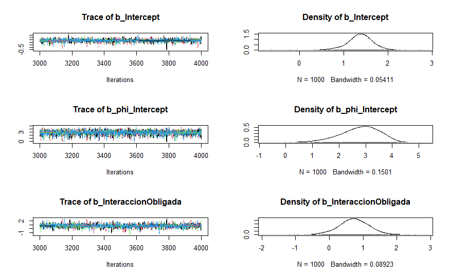

[figure not shown]

```r
plot(as.mcmc(brms_aves3_beta))
```

Verificamos graficamente si la distribución de densidad estimada de los parametros ($B_o$ y $B_1$) incluye al cero.

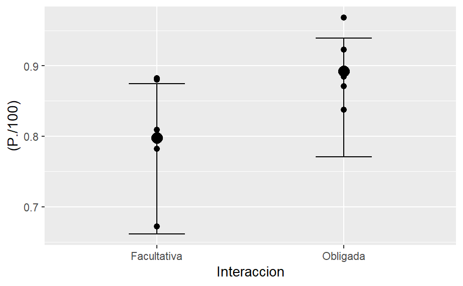

```r
plot(conditional_effects(brms_aves3_beta),points =T)
```

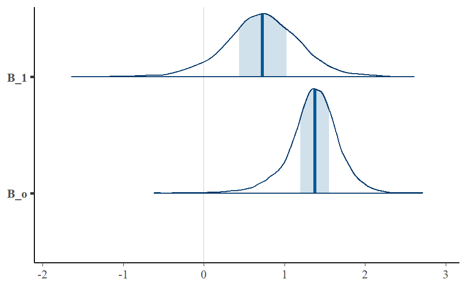

```r
mcmc_areas(as.matrix(brms_aves3_beta),  regex_pars = c("b_Intercept", "b_InteraccionObligada"))+
scale_y_discrete(labels = c("b_Intercept"= "B_o", "b_InteraccionObligada" = "B_1"))
```

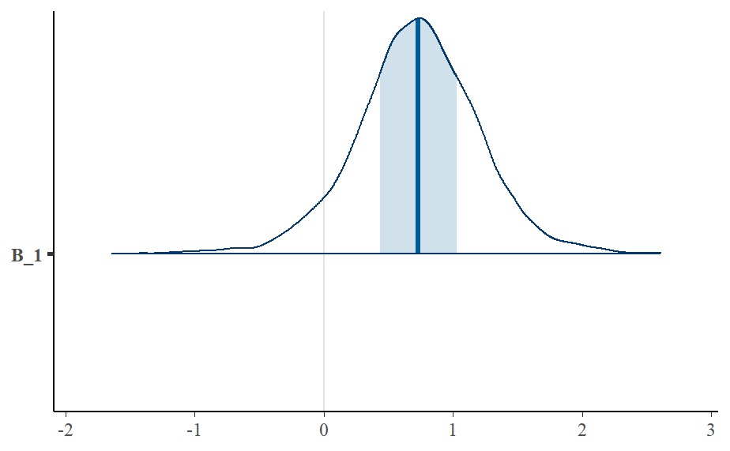

```r
mcmc_areas(as.matrix(brms_aves3_beta),  regex_pars = c("b_InteraccionObligada"))+
scale_y_discrete(labels = c("b_InteraccionObligada" = "B_1"))
```

Otra manera de verificarlo es por medio del comandy hypothesis. En este caso vemos que no es mayor que cero.

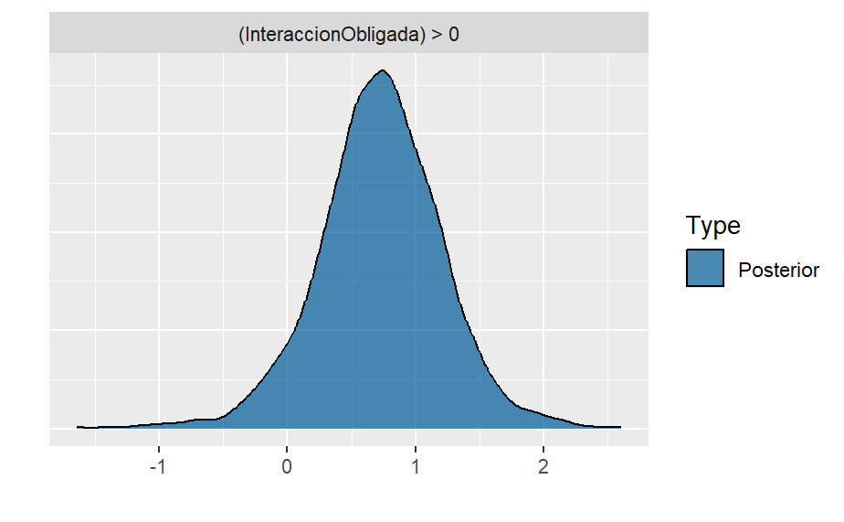

```r
h<- c("InteraccionObligada > 0")
hyp <- hypothesis(brms_aves3_beta, h)
plot(hyp)
```

Arreglo de datos para graficamente observar la distribución de densidades estimada del porcentaje de traslape para las especies de aves que siguen hormigas de acuerdo a la intesidad de la interacción.

```r
posterior_b <- brms_aves3_beta %>%
  gather_draws(`b_.*`, regex = TRUE)
## Facultativa

b_facultativa <- as.data.frame((plogis(posterior_b$.value[posterior_b$.variable== "b_Intercept"]))*100)
colnames(b_facultativa) <- c("esperado")
b_facultativa$Interaccion <- c("Facultativa")
b_facultativa$Interaccion_2 <- c("Facultative ant-following birds")
b_facultativa$T_n<- c("2")



b_obligada <- as.data.frame((plogis(posterior_b$.value[posterior_b$.variable== "b_InteraccionObligada"]+ posterior_b$.value[posterior_b$.variable== "b_Intercept"]))*100)
colnames(b_obligada) <- c("esperado")
b_obligada$Interaccion<- c("Obligada")
b_obligada$Interaccion_2 <- c("Obligate ant-following birds")
b_obligada$T_n <- c("1")


b <- rbind(b_facultativa, b_obligada)
```

```r
mean (b_obligada$esperado)
```

```
[1] 88.35749
```

```r
quantile (b_obligada$esperado, probs = c(0.025, 0.975))
```

```
    2.5%    97.5%
77.10159 93.88298
```

```r
mean (b_facultativa$esperado)
```

```
[1] 79.11877
```

```r
quantile (b_facultativa$esperado, probs = c(0.025, 0.975))
```

```
    2.5%    97.5%
66.09685 87.42198
```

Figura de la distribución de densidades esperadas para el porcentaje de traslape de acuerdo a la intensidad de la interacción.

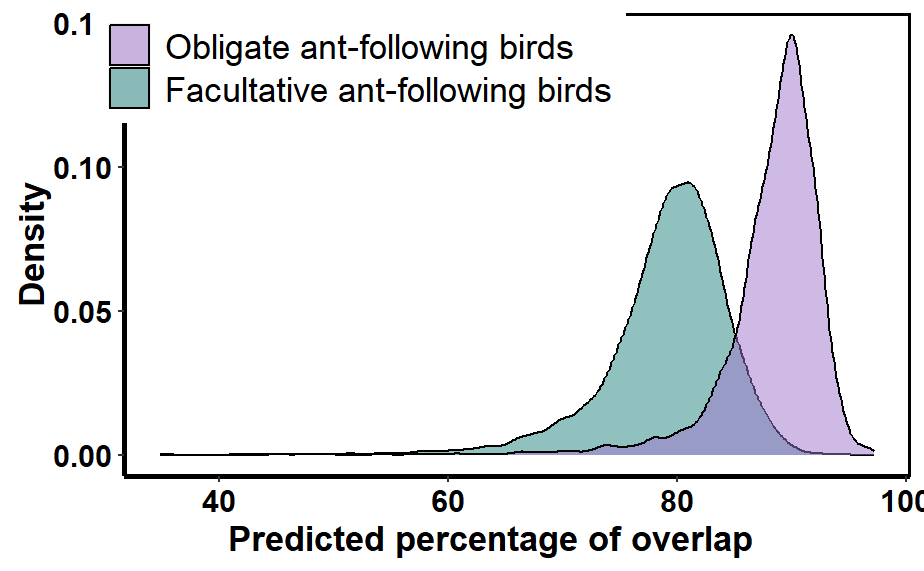

```r
traslape_aves <-ggplot2.density (data= b, xName = "esperado", groupName = "Interaccion_2",
                 alpha=0.5, fillGroupDensity = T,  xtitle = "Predicted percentage of overlap", ytitle=   "Density", groupColors=c('#218380', "#9D75CB"))+
guides(fill = guide_legend(reverse = TRUE))+
theme(legend.position = c(.3, .9), legend.title=element_blank(), axis.line = element_line(linewidth =1, colour="black"),
        #axis.text.x = element_blank(),
        axis.line.y.left = element_line(linewidth = 0.8, colour = "black"),
        panel.background = element_rect(fill = "white"),
        #strip.background = element_rect(colour = "white", fill = "white"),
        #strip.text = element_text(size = 18),
        axis.text=element_text(size=18),
        axis.title=element_text(size=18,face="bold"),
        legend.text=element_text(size=14),
        panel.border = element_rect(colour = "black", fill=NA, size=1),
        plot.title = element_text(hjust = 0.5, size= 18)
  )

traslape_aves
```

El traslape de los intervalos se observa claramente en la siguiente figura

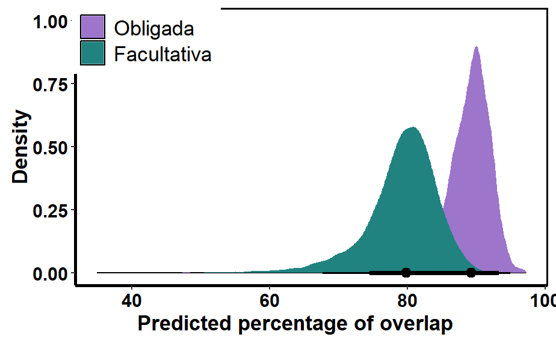

```r
ggplot2.density (data= beta_bayes_pred, xName = "Percentage", groupName = "Interaccion",
                 alpha=0.5, fillGroupDensity = T,  xtitle = "Predicted percentage of overlap", ytitle=   "Density", groupColors=c('#218380', "#9D75CB"))+
  stat_halfeye(.width = c(0.8, 0.95), point_interval = "median_hdi") +
guides(fill = guide_legend(reverse = TRUE))+
theme(legend.position = c(.15, .9), legend.title=element_blank(), axis.line = element_line(linewidth =1, colour="black"),
        #axis.text.x = element_blank(),
        axis.line.y.left = element_line(linewidth = 0.8, colour = "black"),
        panel.background = element_rect(fill = "white"),
        #strip.background = element_rect(colour = "white", fill = "white"),
        #strip.text = element_text(size = 18),
        axis.text=element_text(size=18),
        axis.title=element_text(size=18,face="bold"),
        legend.text=element_text(size=14),
        panel.border = element_rect(colour = "black", fill=NA, size=1),
        plot.title = element_text(hjust = 0.5, size= 18)
  )
```

El efecto marginal de la intensidad de la interacción es en promedio de 9% (resta entre los porcentajes de traslape de aves obligadas - facultativas), sin embargo su intervalo va de -4.5% a 22.9%. Lo que nos confirma que no tenemos evidencia de que la intensidad de la interacción afecte el porcentaje de traslape.

```r
emmeans(brms_aves3_beta, ~ Interaccion,
        regrid = "response") %>%
  contrast(method = "revpairwise")
```

```
 contrast               estimate lower.HPD upper.HPD
 Obligada - Facultativa   0.0908    -0.045     0.229

Point estimate displayed: median
HPD interval probability: 0.95
```

Observamos graficamente el intervalo del efecto marginal de la intensidad de la interacción.

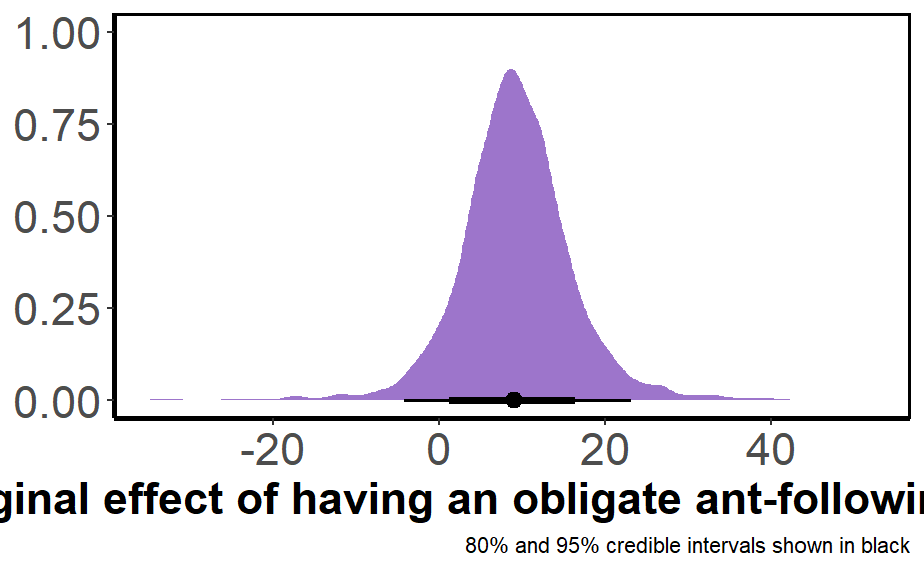

```r
marginal_effects <- as.data.frame( b$esperado[b$Interaccion == "Obligada"] - b$esperado[b$Interaccion=="Facultativa"])
colnames(marginal_effects) <- c("Marginal")

ggplot(marginal_effects, aes(x = Marginal)) +
  stat_halfeye(.width = c(0.8, 0.95), point_interval = "median_hdi",
               fill = "#9d75cb") +
  labs(x = "Average marginal effect of having an obligate ant-following bird interaction",
       y = NULL, caption = "80% and 95% credible intervals shown in black") +
 theme(legend.position = "None", legend.title=element_blank(), axis.line = element_line(linewidth =1, colour="black"),
        #axis.text.x = element_blank(),
        axis.line.y.left = element_line(linewidth = 0.8, colour = "black"),
        panel.background = element_rect(fill = "white"),
        #strip.background = element_rect(colour = "white", fill = "white"),
        #strip.text = element_text(size = 18),
        axis.text=element_text(size=18),
        axis.title=element_text(size=18,face="bold"),
        legend.text=element_text(size=14),
        panel.border = element_rect(colour = "black", fill=NA, size=1),
        plot.title = element_text(hjust = 0.5, size= 18)
  )
```

```r
NA
NA
```

Area

```r
brms_area <- brm( area_km2 ~ Int , data=area, chains =4, iter = 4000, warmup = 3000, family =student, prior = NULL, cores = 4)
#brms_CN <- brm(log(CN) ~ Species, data= base_p, chains =4, iter = 4000, warmup = 3000, family =student, prior = NULL )
```